# 431 Class 12

Thomas E. Love, Ph.D.

2025-10-09

## Today’s Agenda

Contingency Tables (Sections 13-14 in Course Book)

- Some Reminders about 2 x 2 tables
- Building a J x K Table
- Chi-Square Tests of Independence
  - Cochran Conditions and Checking Assumptions

## Today’s Packages

```r
library(janitor)
library(patchwork)
library(easystats)
library(tidyverse)

theme_set(theme_bw())

source("c12/data/Love-431.R")
```

## TB Prevalence in IV Drug Users

Suppose now that we are investigating factors affecting tuberculosis prevalence among intravenous drug users.

- Among 97 individuals who admit to sharing needles,
  - 24 (24.7%) had a positive tuberculin skin test result.
- Among 161 drug users who deny sharing needles,
  - 28 (17.4%) had a positive test result.

What does the 2x2 table look like?

## TB Prevalence In IV Drug Users

The 2x2 Table is…

```
             TB+   TB-
    share     24    73
    don't     28   133
```

- Standard Epidemiological Format
  - rows describe needle sharing
  - columns describe TB test result
- people who share needles: 24 TB+, and 97-24 = 73 TB-
- people who don’t share: 28 TB+ and 161-28 = 133 TB-

## `twobytwo` (with Bayesian Augmentation)

To start, we’ll test the null hypothesis that the population proportions of intravenous drug users who have a positive tuberculin skin test result are identical for those who share needles and those who do not.

$$H_0: \pi_{share} = \pi_{donotshare} \\
H_A: \pi_{share} \neq \pi_{donotshare}$$

We’ll use the Bayesian augmentation.

## `twobytwo` results (95% CI)

```r
twobytwo(24+2, 73+2, 28+2, 133+2,
         "Sharing", "Not Sharing",
         "TB test+", "TB test-", conf.level = 0.95)
```

```
2 by 2 table analysis:
------------------------------------------------------
Outcome   : TB test+
Comparing : Sharing vs. Not Sharing

            TB test+ TB test-    P(TB test+) 95% conf. interval
Sharing           26       75         0.2574    0.1816   0.3513
Not Sharing       30      135         0.1818    0.1301   0.2482

                                   95% conf. interval
             Relative Risk: 1.4158    0.8910   2.2498
         Sample Odds Ratio: 1.5600    0.8594   2.8318
Conditional MLE Odds Ratio: 1.5572    0.8189   2.9511
    Probability difference: 0.0756   -0.0244   0.1819

             Exact P-value: 0.1638
        Asymptotic P-value: 0.1438
------------------------------------------------------
```

## Change to 90% confidence?

- What if we use a 90% confidence level instead?

```
2 by 2 table analysis:
------------------------------------------------------
Outcome   : TB test+
Comparing : Sharing vs. Not Sharing

            TB test+ TB test-    P(TB test+) 90% conf. interval
Sharing           26       75         0.2574    0.1925   0.3351
Not Sharing       30      135         0.1818    0.1375   0.2365

                                   90% conf. interval
             Relative Risk: 1.4158    0.9599   2.0884
         Sample Odds Ratio: 1.5600    0.9458   2.5729
Conditional MLE Odds Ratio: 1.5572    0.9023   2.6818
    Probability difference: 0.0756   -0.0088   0.1646

             Exact P-value: 0.1638
        Asymptotic P-value: 0.1438
------------------------------------------------------
```

# Larger Contingency Tables

## A $2 \times 3$ contingency table

This table displays the count of patients who show *complete*, *partial*, or *no response* after treatment with either **active** medication or a **placebo** in a study of 100 patients…

| Group | None | Partial | Complete |
| --- | --- | --- | --- |
| Active | 8 | 24 | 20 |
| Placebo | 12 | 26 | 10 |

Is there a meaningful association here?

## The Pearson Chi-Square Test

- $H_0$: Response Distribution is the same, regardless of Treatment.
- $H_A$: There is an association between Treatment and Response.

The Pearson $\chi^2$ test assumes the null hypothesis is true (rows and columns are independent.) That is a model for our data. How does it work?

## Calculating Chi-Square

Here’s the table, with marginal totals added.

| – | None | Partial | Complete | **TOTAL** |
| --- | --- | --- | --- | --- |
| Active | 8 | 24 | 20 | **52** |
| Placebo | 12 | 26 | 10 | **48** |
| **TOTAL** | **20** | **50** | **30** | **100** |

The test needs to estimate the expected frequency in each of the six cells under the assumption of independence. If the rows and columns were independent, what is the expected count in the Active/None cell?

## The Independence Model

| – | None | Partial | Complete | **TOTAL** |
| --- | --- | --- | --- | --- |
| Active | – | – | – | **52** |
| Placebo | – | – | – | **48** |
| **TOTAL** | **20** | **50** | **30** | **100** |

If the rows and columns were independent, then:

- 20/100 of subjects would have response = “None”
  - That’s 20% of the 52 Active, and 20% of the 48 Placebo
- 50% would have a “Partial” and 30% would have a “Complete” response in each group.

## Observed (*Expected*) Cell Counts

So, can we fill in the expected frequencies under our independence model?

| – | None | Partial | Complete | **TOTAL** |
| --- | --- | --- | --- | --- |
| Active | 8 (*10.4*) | 24 (*26.0*) | 20 (*15.6*) | **52** |
| Placebo | 12 (*9.6*) | 26 (*24.0*) | 10 (*14.4*) | **48** |
| **TOTAL** | **20** | **50** | **30** | **100** |

## General Formula for Expected Frequencies under Independence

$$\mbox{Expected Frequency} = \frac{\mbox{Row total} \times \mbox{Column total}}{\mbox{Grand Total}}$$

This assumes that the independence model holds: the probability of being in a particular column is exactly the same in each row, and vice versa.

## Chi-Square Assumptions

- Expected Frequencies: We assume that the expected frequency, under the null hypothesized model of independence, will be **at least 5** (and ideally at least 10) in each cell. If that is not the case, then the $\chi^2$ test is likely to give unreliable results.
- The *Cochran conditions* require us to have no cells with zero counts **and** at least 80% of the cells in our table with expected counts of 5 or higher. That’s what R uses to warn you of trouble.
- Miss the standards? Consider collapsing categories.

## Observed (**Expected**) Cell Counts (again)

| – | None | Partial | Complete | **TOTAL** |
| --- | --- | --- | --- | --- |
| Active | 8 (**10.4**) | 24 (**26.0**) | 20 (**15.6**) | 52 |
| Placebo | 12 (**9.6**) | 26 (**24.0**) | 10 (**14.4**) | 48 |
| TOTAL | 20 | 50 | 30 | 100 |

- Do we meet the Cochran conditions in this case?

## Getting the Table into R

We’ll put the table into a matrix in R. Here’s one approach…

```r
T1 <- matrix(c(8, 24, 20, 12, 26, 10),
             ncol=3, nrow=2, byrow=TRUE)
rownames(T1) <- c("Active", "Placebo")
colnames(T1) <- c("None", "Partial", "Complete")
T1
```

```
        None Partial Complete
Active     8      24       20
Placebo   12      26       10
```

```r
chisq.test(T1)
```

```
    Pearson's Chi-squared test

data:  T1
X-squared = 4.0598, df = 2, p-value = 0.1313
```

## Chi-Square Test Results in R

- $H_0$: Response Distribution is the same, regardless of Treatment.
  - Rows and Columns of the table are *independent*
- $H_A$: There is an association between Treatment and Response.
  - Rows and Columns of the table are *associated*.
- For our T1: $\chi^2$ = 4.0598, df = 2, *p* = 0.1313

What is the conclusion?

## Does Sample Size Affect $\chi^2$?

- T1 results were: $\chi^2$ = 4.0598, df = 2, *p* = 0.1313
- Suppose we had same pattern, but twice the data?

```r
T1_doubled <- T1*2
T1_doubled
```

```
        None Partial Complete
Active    16      48       40
Placebo   24      52       20
```

```r
chisq.test(T1_doubled)
```

```
    Pearson's Chi-squared test

data:  T1_doubled
X-squared = 8.1197, df = 2, p-value = 0.01725
```

## Fisher’s exact test instead?

Yes, but … if the Pearson assumptions don’t hold, then the Fisher’s test is not generally an improvement.

```r
fisher.test(T1)
```

```
    Fisher's Exact Test for Count Data

data:  T1
p-value = 0.1358
alternative hypothesis: two.sided
```

- Intended for small-ish square tables, with the same number of rows as columns.

## Returning to the DM464 data

- We discussed these data (other variables) in Classes 5-6.

```r
dm12 <- read_csv("c12/data/dm464_class12.csv", show_col_types = FALSE) |>
  janitor::clean_names() |>
  mutate(tobacco = fct_relevel(tobacco, "Current", "Former"),
         insurance = fct_relevel(insurance, "Medicare",
                                 "Commercial", "Medicaid"))

dm12 |> tabyl(tobacco, insurance) |>
    adorn_totals(where = c("row", "col"))
```

```
 tobacco Medicare Commercial Medicaid Total
 Current       33          8       76   117
  Former       92         23       71   186
   Never       68         30       63   161
   Total      193         61      210   464
```

## dm12: Bar Plots with Counts

```r
p1 <- ggplot(dm12, aes(x = insurance)) +
      geom_bar(aes(fill = insurance)) +
      geom_text(aes(label = ..count..), stat = "count",
                vjust = 1.5, col = "black") +
      scale_fill_oi() +  ## from see package
      guides(fill = "none")

p2 <- ggplot(dm12, aes(x = tobacco)) +
      geom_bar(aes(fill = tobacco)) +
      geom_text(aes(label = ..count..), stat = "count",
                vjust = 1.5, col = "white") +
      scale_fill_metro() +  ## from see package
      guides(fill = "none")

p1 + p2
```

## dm12: Bar Plots with Counts

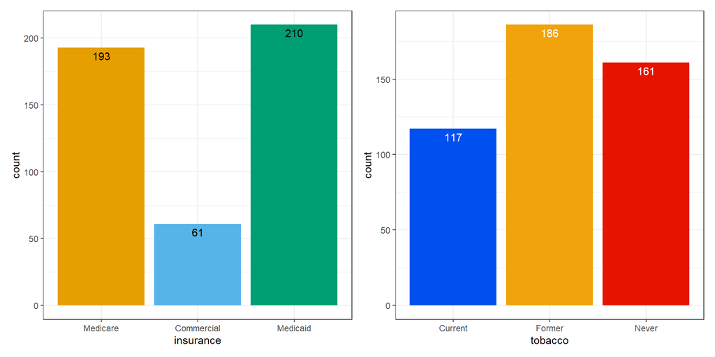

## A $3 \times 3$ table with the `dm12` data

```r
dm12 |>
    tabyl(insurance, tobacco) |>
    adorn_totals(where = c("row", "col"))
```

```
  insurance Current Former Never Total
   Medicare      33     92    68   193
 Commercial       8     23    30    61
   Medicaid      76     71    63   210
      Total     117    186   161   464
```

## Plotting a Cross-Tabulation?

```r
ggplot(dm12, aes(x = insurance, y = tobacco)) +
    geom_count()
```

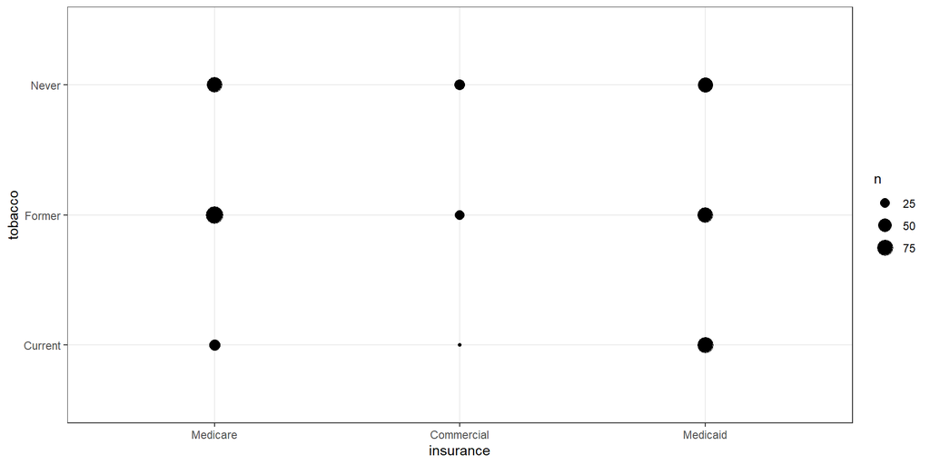

## Tobacco Bar Chart faceted by Insurance

```r
ggplot(dm12, aes(x = tobacco, fill = tobacco)) +
    geom_bar() +
    facet_wrap(~ insurance) +
    scale_fill_pizza() +  ## also from see package
    guides(fill = "none") +
    geom_text(aes(label = ..count..), stat = "count",
              vjust = -0.5, col = "navy")
```

## Tobacco Bar Chart faceted by Insurance

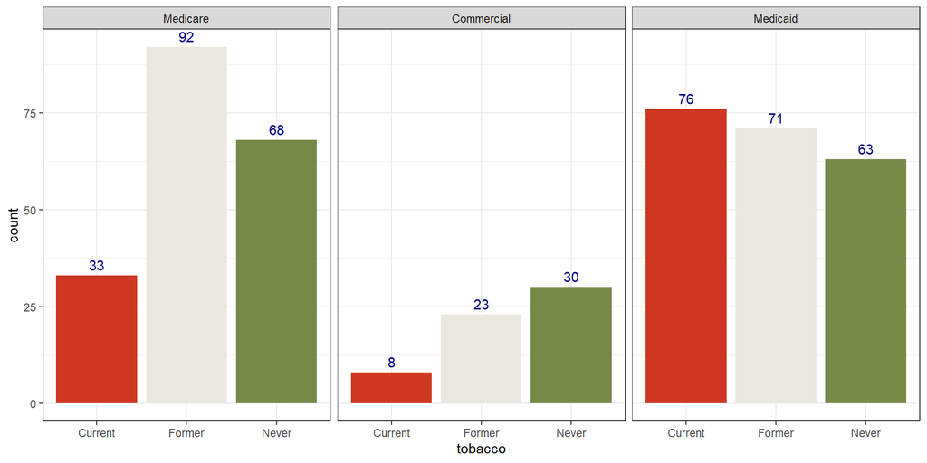

## `dm12` Tobacco and Insurance

- $H_0$: Insurance type and Tobacco status are independent
- $H_A$: Insurance type and Tobacco status are associated

```r
dm12 |> tabyl(insurance, tobacco) |> chisq.test()
```

```
    Pearson's Chi-squared test

data:  tabyl(dm12, insurance, tobacco)
X-squared = 28.574, df = 4, p-value = 9.542e-06
```

Can we check our expected frequencies?

## Checking Expected Frequencies

```r
res <- dm12 |> tabyl(insurance, tobacco) |> chisq.test()

res$observed
```

```
  insurance Current Former Never
   Medicare      33     92    68
 Commercial       8     23    30
   Medicaid      76     71    63
```

```r
res$expected
```

```
  insurance  Current   Former    Never
   Medicare 48.66595 77.36638 66.96767
 Commercial 15.38147 24.45259 21.16595
   Medicaid 52.95259 84.18103 72.86638
```

Any problems with Cochran conditions?

## Mosaic Plot for Cross-Tabulation

Each rectangle’s area is proportional to the number of cases in that cell.

```r
plot(dm12$insurance, dm12$tobacco, ylab = "", xlab = "")
```

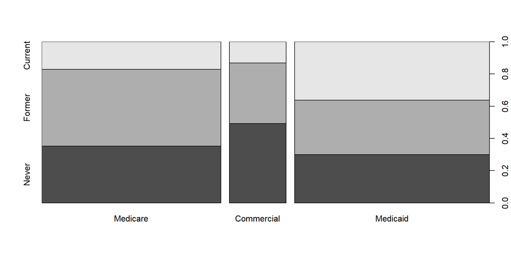